# Charles Jones

Computer Science PhD student @ Imperial College London

Microsoft Research Scholarship in Machine Learning for Medical Imaging

Incoming Enrichment Scheme Student @ Alan Turing Institute

Hi!

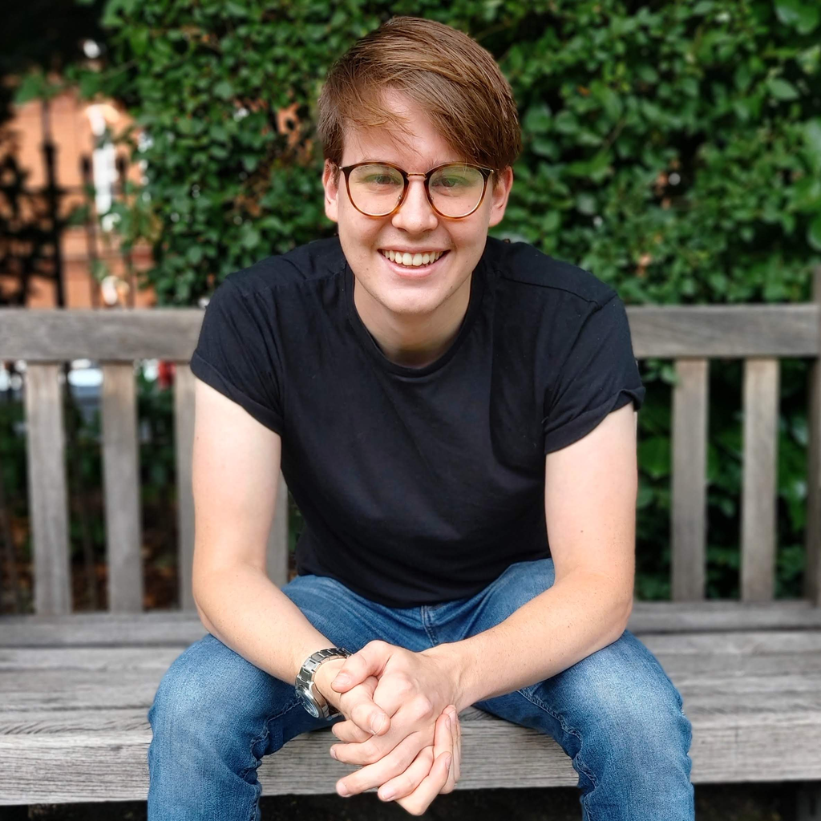

I am a Computer Science (machine learning) PhD student, advised by Ben Glocker at Imperial College London. My research focuses on **Causal Deep Learning for Fair and Robust Medical AI**. I am interested in all things involving deep learning, causal inference/discovery, and how we can combine these fields to solve problems in medical imaging and the wider AI community.

I occasionally write blog posts about side projects and things I’ve learned along my programming journey. If you’re interested in discussing anything from this blog, consider reaching out (my contact details are in the footer). You can also create an issue on this website’s [GitHub repo](https://github.com/Charl-AI/Charl-AI.github.io).

This website is generated using only pandoc and a shell script. If you’re interested in finding out more, check out the blog post I wrote about it!

Contact: [[GitHub]](https://github.com/Charl-AI) [[Scholar]](https://scholar.google.com/citations?user=4PLajkUAAAAJ&hl=en) [[LinkedIn]](https://www.linkedin.com/in/charles-jones1917/) [Mail] [[Twitter]](https://twitter.com/c_jones_ai)